# Check the Potr genomes gene overlap, pairwise, with reciprocal 30% coverage

Nicolas Delhomme

2015-06-16

# 1 Setup

Set the working dir

```r
setwd("/mnt/picea/projects/aspseq/asp201/rna/BEDTools/")
```

Load libraries

```r
suppressPackageStartupMessages(library(igraph))
suppressPackageStartupMessages(library(matrixStats))
suppressPackageStartupMessages(library(pander))
suppressPackageStartupMessages(library(parallel))
```

# 2 Perform the assessment

Reading in all the pairwise intersect data

```r
res <- mclapply(dir(".",pattern=".*-30p-recip\\.tsv"),read.delim,
                stringsAsFactors=FALSE,header=FALSE,mc.cores=6L)

names(res) <- sub("-70p-recip\\.tsv","",dir(".",pattern=".*-30p-recip\\.tsv"))
```

Create a list of edges

```r
edges.list <- lapply(res,"[",c(9,18))
edges.list <- lapply(edges.list,function(edges){
  cbind(sub(";.*","",sub(".*Name=","",edges[,1])),
        gsub(".*Name=|\\.0$","",edges[,2]))})
```

Report on the number of links and the number of missing

```r
stats <- do.call(rbind,lapply(edges.list,function(edges){
  tab <- table(table(edges[,2]))
  mult <- rep(as.integer(names(tab[-c(1,length(tab))])),tab[-c(1,length(tab))])
  c(total=nrow(edges),
    gene=length(unique(edges[,1])),
    gene.mapped=length(unique(edges[,2]))-1,
    gene.unique.mapped=sum(table(edges[,2])==1),
    gene.multi=sum(table(edges[,2])>1) - 1,
    gene.multi.mean=mean(mult),
    gene.multi.median=median(mult),
    gene.multi.sd=sd(mult),
    gene.multi.min=min(mult),
    gene.multi.max=max(mult),
    gene.missed=sum(edges[,2]==".")
    )
}))
```

Print it

```r
pander(stats)
```

Table continues below

|  | total | gene | gene.mapped |
| --- | --- | --- | --- |
| **Potra01-Potri03-30p-recip.tsv** | 46578 | 36144 | 34485 |
| **Potra01-Potrs01-30p-recip.tsv** | 44229 | 36144 | 32829 |
| **Potri03-Potra01-30p-recip.tsv** | 44730 | 41335 | 30676 |
| **Potri03-Potrs01-30p-recip.tsv** | 44640 | 41335 | 30348 |
| **Potrs01-Potra01-30p-recip.tsv** | 46492 | 37778 | 33614 |
| **Potrs01-Potri03-30p-recip.tsv** | 47221 | 37778 | 34518 |

Table continues below

|  | gene.unique.mapped | gene.multi |
| --- | --- | --- |
| **Potra01-Potri03-30p-recip.tsv** | 30082 | 4403 |
| **Potra01-Potrs01-30p-recip.tsv** | 28139 | 4690 |
| **Potri03-Potra01-30p-recip.tsv** | 28274 | 2402 |
| **Potri03-Potrs01-30p-recip.tsv** | 27983 | 2365 |
| **Potrs01-Potra01-30p-recip.tsv** | 27457 | 6157 |
| **Potrs01-Potri03-30p-recip.tsv** | 29772 | 4746 |

Table continues below

|  | gene.multi.mean |
| --- | --- |
| **Potra01-Potri03-30p-recip.tsv** | 2.628 |
| **Potra01-Potrs01-30p-recip.tsv** | 2.588 |
| **Potri03-Potra01-30p-recip.tsv** | 2.125 |
| **Potri03-Potrs01-30p-recip.tsv** | 2.116 |
| **Potrs01-Potra01-30p-recip.tsv** | 2.443 |
| **Potrs01-Potri03-30p-recip.tsv** | 2.277 |

Table continues below

|  | gene.multi.median |
| --- | --- |
| **Potra01-Potri03-30p-recip.tsv** | 2 |
| **Potra01-Potrs01-30p-recip.tsv** | 2 |
| **Potri03-Potra01-30p-recip.tsv** | 2 |
| **Potri03-Potrs01-30p-recip.tsv** | 2 |
| **Potrs01-Potra01-30p-recip.tsv** | 2 |
| **Potrs01-Potri03-30p-recip.tsv** | 2 |

Table continues below

|  | gene.multi.sd | gene.multi.min |
| --- | --- | --- |
| **Potra01-Potri03-30p-recip.tsv** | 4.934 | 2 |
| **Potra01-Potrs01-30p-recip.tsv** | 2.192 | 2 |
| **Potri03-Potra01-30p-recip.tsv** | 0.4274 | 2 |
| **Potri03-Potrs01-30p-recip.tsv** | 0.4129 | 2 |
| **Potrs01-Potra01-30p-recip.tsv** | 0.9147 | 2 |
| **Potrs01-Potri03-30p-recip.tsv** | 0.6845 | 2 |

|  | gene.multi.max | gene.missed |
| --- | --- | --- |
| **Potra01-Potri03-30p-recip.tsv** | 94 | 4924 |
| **Potra01-Potrs01-30p-recip.tsv** | 94 | 3951 |
| **Potri03-Potra01-30p-recip.tsv** | 5 | 11352 |
| **Potri03-Potrs01-30p-recip.tsv** | 5 | 11652 |
| **Potrs01-Potra01-30p-recip.tsv** | 8 | 3995 |
| **Potrs01-Potri03-30p-recip.tsv** | 10 | 6641 |

Graph the edges list

```r
edges.graf <- lapply(lapply(edges.list,function(edges){edges[edges[,2]!=".",]}),
                      graph.edgelist,directed=FALSE)
```

Get their stats

```r
graf.stats <- do.call(rbind,lapply(edges.graf,function(graf){
  cl <- clusters(graf)
  c(clusters=cl$no,
    singleton=sum(cl$csize==2),
    multiple=length(cl$csize[cl$csize>2]),
    mean=mean(cl$csize[cl$csize>2]-1),
    median=median(cl$csize[cl$csize>2]-1),
    sd=sd(cl$csize[cl$csize>2]-1),
    min=min(cl$csize[cl$csize>2]-1),
    max=max(cl$csize[cl$csize>2]-1))
}))
```

And print them

```r
pander(graf.stats)
```

Table continues below

|  | clusters | singleton |
| --- | --- | --- |
| **Potra01-Potri03-30p-recip.tsv** | 27626 | 22582 |
| **Potra01-Potrs01-30p-recip.tsv** | 28255 | 23975 |
| **Potri03-Potra01-30p-recip.tsv** | 27792 | 24638 |
| **Potri03-Potrs01-30p-recip.tsv** | 27397 | 24034 |
| **Potrs01-Potra01-30p-recip.tsv** | 28376 | 22933 |
| **Potrs01-Potri03-30p-recip.tsv** | 27174 | 21310 |

Table continues below

|  | multiple | mean | median |
| --- | --- | --- | --- |
| **Potra01-Potri03-30p-recip.tsv** | 5044 | 3.107 | 2 |
| **Potra01-Potrs01-30p-recip.tsv** | 4280 | 3.006 | 2 |
| **Potri03-Potra01-30p-recip.tsv** | 3154 | 2.609 | 2 |
| **Potri03-Potrs01-30p-recip.tsv** | 3363 | 2.557 | 2 |
| **Potrs01-Potra01-30p-recip.tsv** | 5443 | 2.967 | 2 |
| **Potrs01-Potri03-30p-recip.tsv** | 5864 | 2.954 | 2 |

|  | sd | min | max |
| --- | --- | --- | --- |
| **Potra01-Potri03-30p-recip.tsv** | 4.31 | 2 | 114 |
| **Potra01-Potrs01-30p-recip.tsv** | 3.404 | 2 | 95 |
| **Potri03-Potra01-30p-recip.tsv** | 1.877 | 2 | 65 |
| **Potri03-Potrs01-30p-recip.tsv** | 1.38 | 2 | 31 |
| **Potrs01-Potra01-30p-recip.tsv** | 3.126 | 2 | 73 |
| **Potrs01-Potri03-30p-recip.tsv** | 3.623 | 2 | 102 |

Combined graph

```r
graf <- graph.edgelist(do.call(rbind,
                               lapply(edges.list,
                                      function(edges){edges[edges[,2]!=".",]})))
```

Look at the clusters

```r
cl <- clusters(graf)
sprintf("There are %s clusters",cl$no)
```

```
## [1] "There are 26889 clusters"
```

and the table of the cluster sizes

```r
pander(sort(table(cl$csize),decreasing=TRUE),
       caption="Occurence (upper row) of the different cluster sizes (lower row)")
```

Table continues below

| 3 | 4 | 6 | 2 | 5 | 7 | 8 | 9 | 10 | 11 |
| --- | --- | --- | --- | --- | --- | --- | --- | --- | --- |
| 17004 | 3233 | 1753 | 1524 | 1181 | 854 | 387 | 229 | 140 | 108 |

Table continues below

| 12 | 13 | 14 | 15 | 16 | 18 | 17 | 20 | 19 | 23 |
| --- | --- | --- | --- | --- | --- | --- | --- | --- | --- |
| 92 | 52 | 51 | 32 | 31 | 24 | 23 | 15 | 9 | 9 |

Table continues below

| 24 | 25 | 21 | 22 | 27 | 33 | 34 | 40 | 26 | 32 |
| --- | --- | --- | --- | --- | --- | --- | --- | --- | --- |
| 9 | 9 | 8 | 7 | 7 | 6 | 6 | 5 | 4 | 4 |

Table continues below

| 39 | 29 | 30 | 31 | 41 | 52 | 56 | 112 | 35 |
| --- | --- | --- | --- | --- | --- | --- | --- | --- |
| 4 | 3 | 3 | 3 | 3 | 3 | 3 | 3 | 2 |

Table continues below

| 36 | 37 | 43 | 44 | 45 | 49 | 54 | 60 | 80 | 28 |
| --- | --- | --- | --- | --- | --- | --- | --- | --- | --- |
| 2 | 2 | 2 | 2 | 2 | 2 | 2 | 2 | 2 | 1 |

Table continues below

| 46 | 47 | 48 | 50 | 51 | 53 | 55 | 57 | 58 | 61 |
| --- | --- | --- | --- | --- | --- | --- | --- | --- | --- |
| 1 | 1 | 1 | 1 | 1 | 1 | 1 | 1 | 1 | 1 |

Table continues below

| 65 | 68 | 74 | 75 | 79 | 84 | 85 | 86 | 87 | 89 |
| --- | --- | --- | --- | --- | --- | --- | --- | --- | --- |
| 1 | 1 | 1 | 1 | 1 | 1 | 1 | 1 | 1 | 1 |

| 106 | 119 | 192 | 203 | 216 | 243 | 307 |
| --- | --- | --- | --- | --- | --- | --- |
| 1 | 1 | 1 | 1 | 1 | 1 | 1 |

Draw some examples

The one with the max vertices

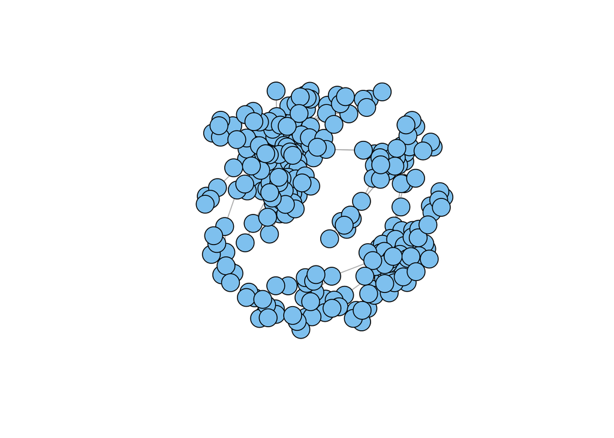

```r
baron <- induced.subgraph(graf,get.vertex.attribute(graf,"name")[which(clusters(graf)$membership == which.max(clusters(graf)$csize))])

plot.igraph(baron,vertex.label=NA,edge.arrow.mode=0)
```

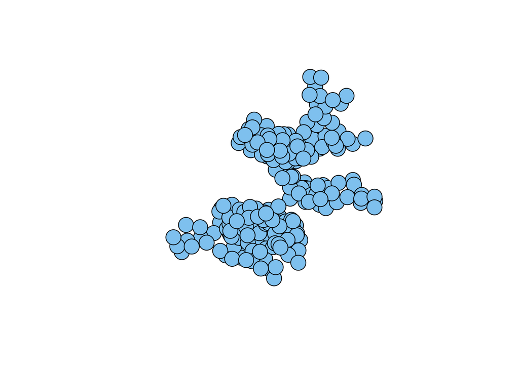

```r
plot.igraph(baron,vertex.label=NA,edge.arrow.mode=0,layout=layout.kamada.kawai(baron))
```

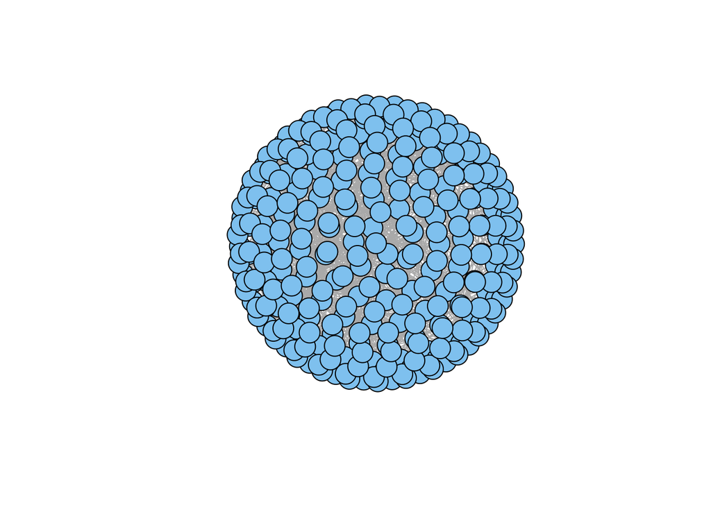

```r
plot.igraph(baron,vertex.label=NA,edge.arrow.mode=0,layout=layout.sphere(baron))
```

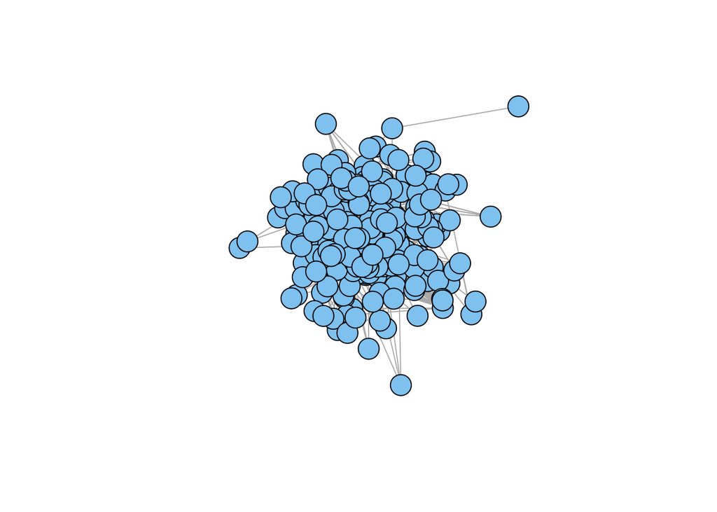

```r
plot.igraph(baron,vertex.label=NA,edge.arrow.mode=0,layout=layout.spring(baron))
```

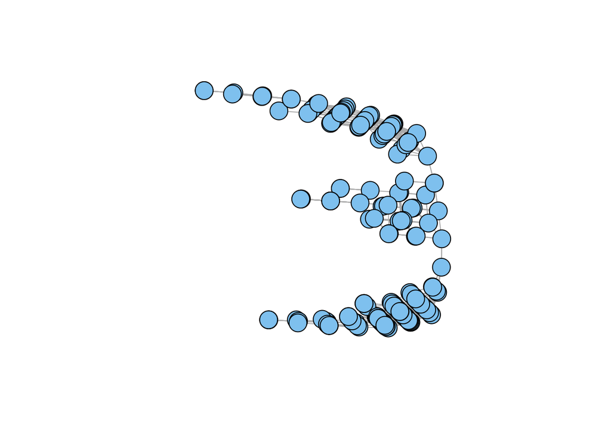

```r
plot.igraph(baron,vertex.label=NA,edge.arrow.mode=0,layout=layout.svd(baron))
```

An example with 3 (the most frequent)

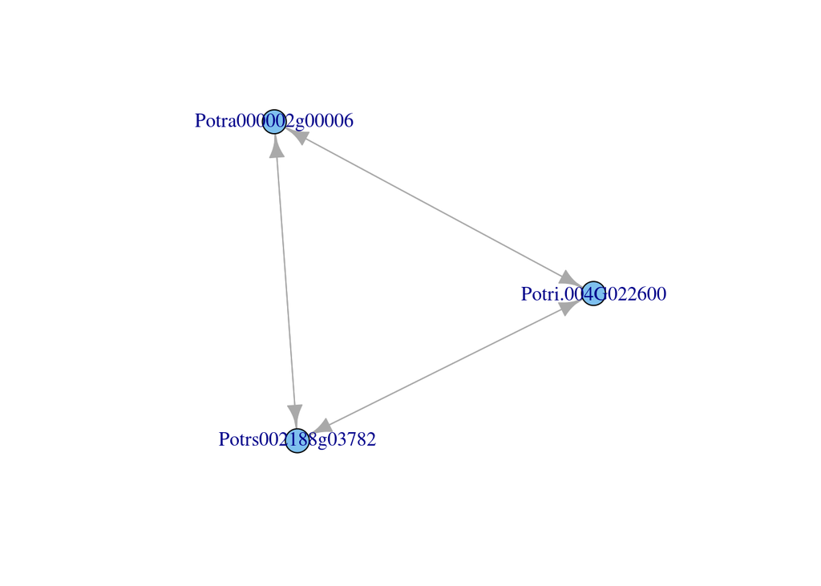

```r
baron <- induced.subgraph(graf,get.vertex.attribute(graf,"name")[which(clusters(graf)$membership == which(clusters(graf)$csize==3)[1])])
plot.igraph(baron)
```

An example with 2

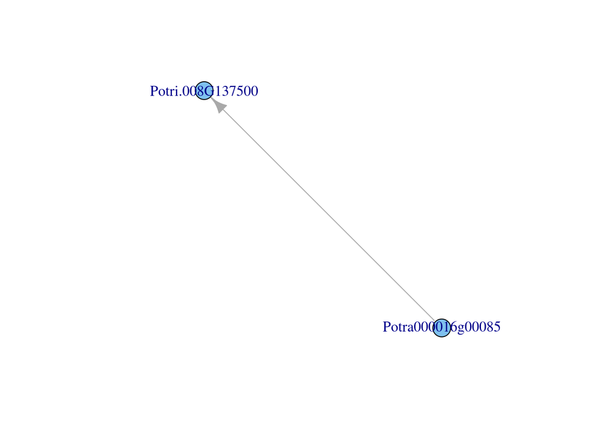

```r
baron <- induced.subgraph(graf,get.vertex.attribute(graf,"name")[which(clusters(graf)$membership == which(clusters(graf)$csize==2)[1])])
plot.igraph(baron)
```

An example with 4

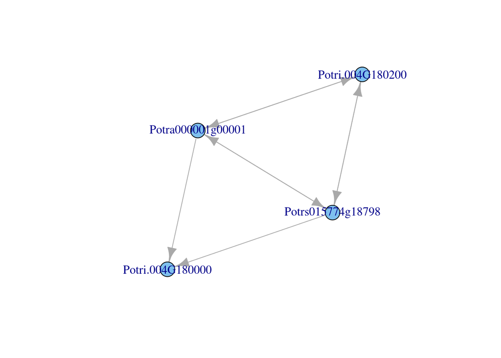

```r
baron <- induced.subgraph(graf,get.vertex.attribute(graf,"name")[which(clusters(graf)$membership == which(clusters(graf)$csize==4)[1])])
plot.igraph(baron)
```

An example with 5

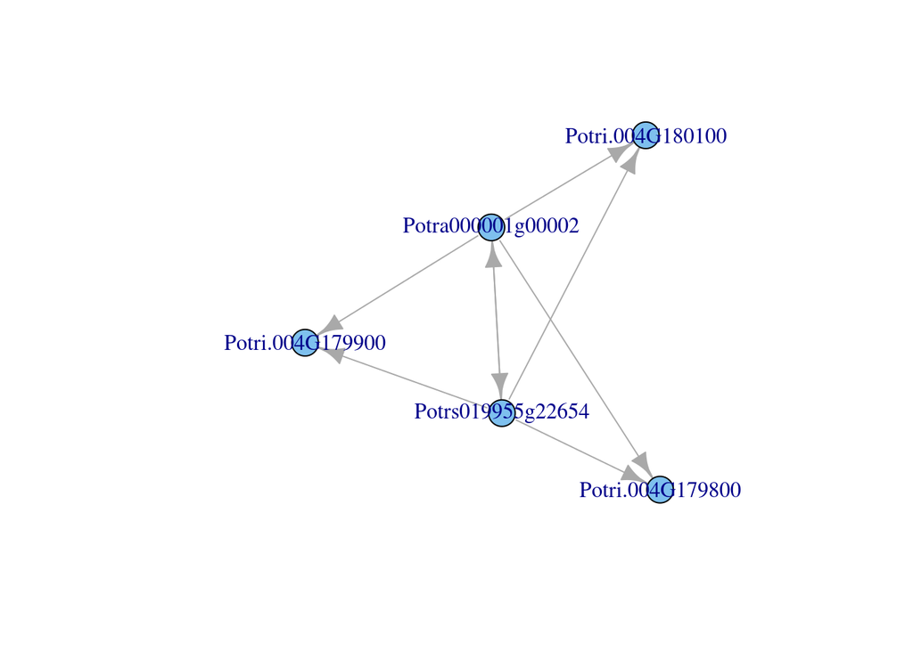

```r
baron <- induced.subgraph(graf,get.vertex.attribute(graf,"name")[which(clusters(graf)$membership == which(clusters(graf)$csize==5)[1])])
plot.igraph(baron)
```

An example with 6

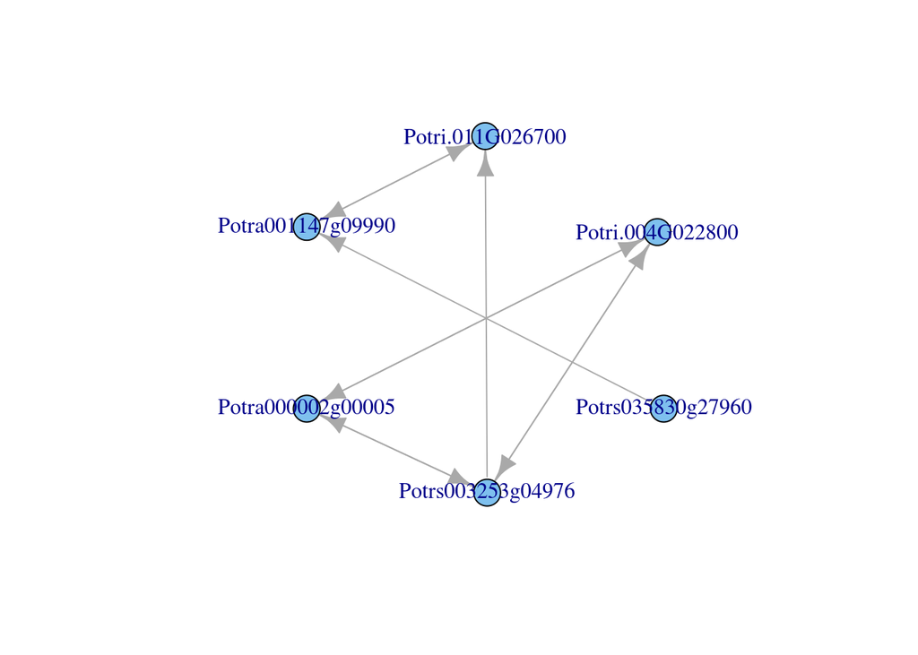

```r
baron <- induced.subgraph(graf,get.vertex.attribute(graf,"name")[which(clusters(graf)$membership == which(clusters(graf)$csize==6)[1])])
plot.igraph(baron,layout=layout.spring(baron))
```

This all looks good, let’s count the number of clusters and how many species are involved in each

```r
cluster.members.mat <- do.call(rbind,lapply(lapply(lapply(split(get.vertex.attribute(graph = graf,name="name"),
                                         clusters(graf)$membership),substr,1,5),
                            factor,levels=c("Potra","Potri","Potrs")),table))
```

Cluster numbers:

```r
nrow(cluster.members.mat)
```

```
## [1] 26889
```

Number of genes per species

```r
pander(colSums(cluster.members.mat))
```

| Potra | Potri | Potrs |
| --- | --- | --- |
| 35529 | 36457 | 36497 |

Number of “absent” gene per species

```r
pander(colSums(cluster.members.mat==0))
```

| Potra | Potri | Potrs |
| --- | --- | --- |
| 381 | 1221 | 485 |

Occurence of the missing genes - mostly one species is missing, but 4 are absent from 2 species

```r
pander(table(rowSums(cluster.members.mat==0)))
```

| 0 | 1 | 2 |
| --- | --- | --- |
| 24806 | 2079 | 4 |

All of them imply 1 gene. The value of one are due to some gene Names not being Potr[a,i,s], but miRNAs

```r
pander(cluster.members.mat[(rowSums(cluster.members.mat==0))==2,])
```

|  | Potra | Potri | Potrs |
| --- | --- | --- | --- |
| **25523** | 0 | 0 | 1 |
| **26813** | 1 | 0 | 0 |
| **26845** | 1 | 0 | 0 |
| **26846** | 1 | 0 | 0 |

Number of unique genes per cluster

```r
pander(table(rowSums(cluster.members.mat==1)))
```

| 0 | 1 | 2 | 3 |
| --- | --- | --- | --- |
| 3596 | 1554 | 5098 | 16641 |

Number of identical number of genes per cluster

```r
sum(rowSds(cluster.members.mat)==0)
```

```
## [1] 18231
```

And their occurences

```r
table(cluster.members.mat[rowSds(cluster.members.mat)==0,1])
```

```
##
##     1     2     3     4     5     6
## 16641  1482    83    21     3     1
```

Number of unique genes per species

```r
pander(colSums(cluster.members.mat==1))
```

| Potra | Potri | Potrs |
| --- | --- | --- |
| 21246 | 19827 | 20600 |

Number of multiple genes per species It would seem like Potra is more collapsed

```r
pander(colSums(cluster.members.mat>1))
```

| Potra | Potri | Potrs |
| --- | --- | --- |
| 5262 | 5841 | 5804 |

Stats of the multiple genes

mean

```r
pander(sapply(1:3,function(i,mat){mean(mat[mat[,i]>1,i])},cluster.members.mat))
```

*2.714*, *2.847* and *2.739*

median

```r
pander(sapply(1:3,function(i,mat){median(mat[mat[,i]>1,i])},cluster.members.mat))
```

*2*, *2* and *2*

max

```r
pander(sapply(1:3,function(i,mat){max(mat[mat[,i]>1,i])},cluster.members.mat))
```

*94*, *150* and *79*

min

```r
pander(sapply(1:3,function(i,mat){min(mat[mat[,i]>1,i])},cluster.members.mat))
```

*2*, *2* and *2*

Number of clusters presents in Potr[as] but not Potri

```r
Potras.clusters <- which(rowSums(cluster.members.mat[,c("Potra","Potrs")] >= 1)==2  & cluster.members.mat[,"Potri"] == 0)
length(Potras.clusters)
```

```
## [1] 1217
```

Number of corresponding genes

```r
sum(clusters(graf)$csize[Potras.clusters])
```

```
## [1] 4007
```

Distribution of the cluster size

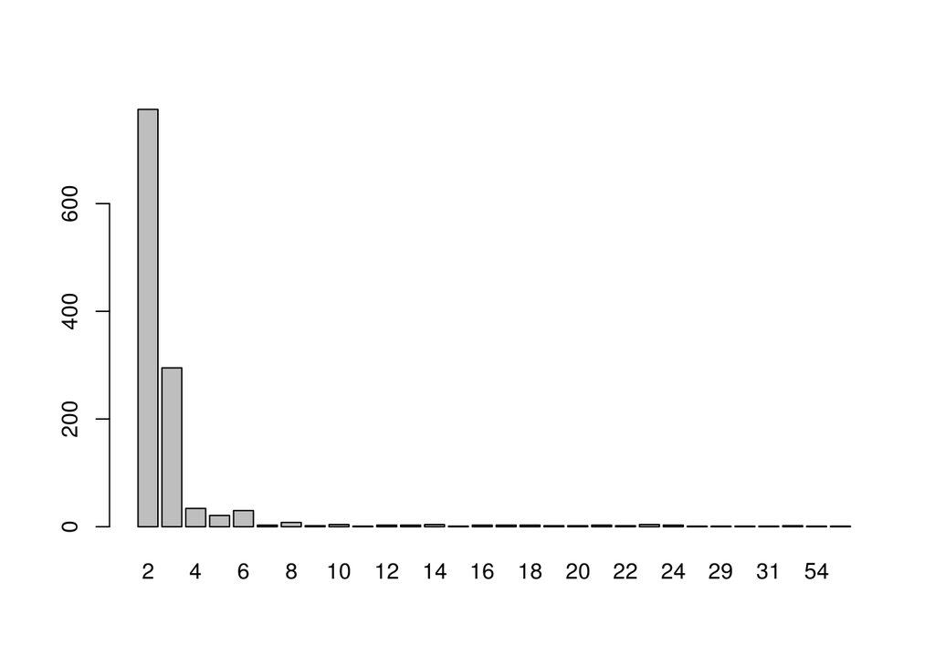

```r
barplot(table(clusters(graf)$csize[Potras.clusters]))
```

Check if one species has more gene than the other (pre cluster Potra - Potrs) We seen to have more copies in Potrs, so Potra appears more collapsed.

```r
pander(table(cluster.members.mat[Potras.clusters,1] - cluster.members.mat[Potras.clusters,3]))
```

Table continues below

| -6 | -5 | -4 | -3 | -2 | -1 | 0 | 1 | 2 | 3 |
| --- | --- | --- | --- | --- | --- | --- | --- | --- | --- |
| 2 | 2 | 4 | 8 | 9 | 137 | 988 | 51 | 12 | 1 |

| 6 | 7 | 8 |
| --- | --- | --- |
| 1 | 1 | 1 |

Get the gene IDs

```r
IDs <- get.vertex.attribute(graf,"name")[which(clusters(graf)$membership %in% Potras.clusters)]
```

If we drop the pre-miRNA

```r
pander(table(substr(IDs[grep("Potra",IDs)],1,5)))
```

| Potra |
| --- |
| 1799 |